# 数学建模

### 编程知识点

### 模型第三方库-statsmodels

**Wang Haihua**

🚅 🚋😜 🚑 🚔

What is the purpose of a **Bayesian dynamic linear model**?  
To adapt quickly to sudden changes in time series trend.

In this liveProject you are tasked with implementing a Bayesian dynamic linear model using the [PyDLM library](https://github.com/wwrechard/PyDLM).

The purpose of this exercise is to build a model that can *adapt to significant changes in a time series trend*. This allows the model to generate forecasts that are more adaptive to changes than classical time series forecasting techniques.

#### In this notebook

- **Milestone 1: Simple Dynamic Linear Model**
  - Tunning
  - Forecast Interpretation
  - RMSE
- **Milestone 2: DLM with Dynamic & Autoregressive Components**
  - Tunning
  - Forecast Interpretation
  - RMSE

```python
import pandas as pd
import numpy as np

import statsmodels.api as sm
from statsmodels.tsa.arima.model import ARIMA
from statsmodels.tsa.seasonal import seasonal_decompose
from statsmodels.graphics.tsaplots import plot_acf, plot_pacf

from sklearn.metrics import mean_squared_error

%matplotlib inline
%config InlineBackend.figure_format='retina'
import matplotlib.pyplot as plt
import seaborn as sns

np.random.seed(42)
idx = pd.IndexSlice
```

```python
!head -n2 data/h2weekly.csv
```

```
Date,IsCanceled
2015-06-21,97
```

```python
ts = pd.read_csv('data/h2weekly.csv', parse_dates=['Date'], index_col='Date', squeeze=True)

type(ts)
ts.head(2)
ts.tail(2)
```

```
pandas.core.series.Series
```

```
Date
2015-06-21     97
2015-06-28    153
Name: IsCanceled, dtype: int64
```

```
Date
2017-08-20    201
2017-08-27    129
Name: IsCanceled, dtype: int64
```

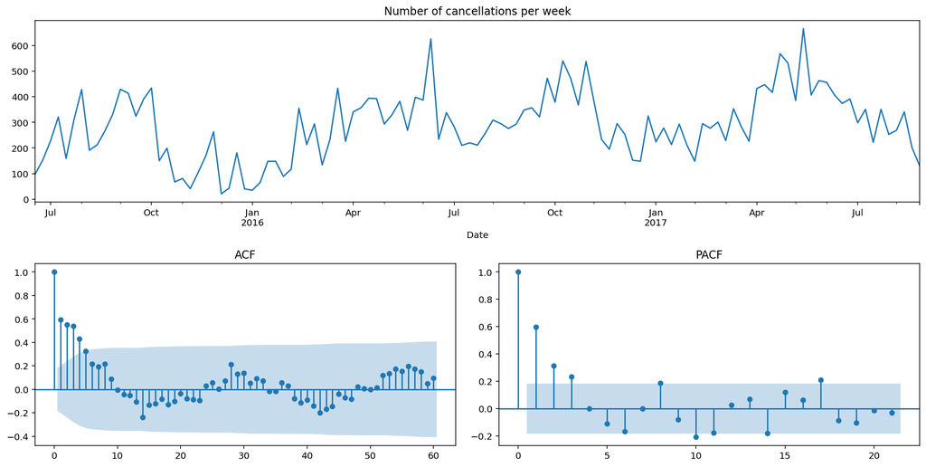

```python
fig = plt.figure(constrained_layout=True, figsize=(14, 7))
gs = fig.add_gridspec(2, 2)

ax_top = fig.add_subplot(gs[0, :])
ax_bot_0 = fig.add_subplot(gs[1, 0])
ax_bot_1 = fig.add_subplot(gs[1, 1])

_ = ts.plot(ax=ax_top, title='Number of cancellations per week')
_ = plot_acf(ts, ax=ax_bot_0, title='ACF', lags=60)
_ = plot_pacf(ts, ax=ax_bot_1, title='PACF')
```

## Milestone 1: Simple Dynamic Linear Model

To the Top

The [Google data science post example](https://pydlm.github.io/example1.html) as provided by the [PyDLM](https://pydlm.github.io/) documentation was used as a template in building the below models.

Here are some relevant technical terms describing the parameters in the models below:

- **degree** = Autoregressive component, i.e. how many previous time periods to incorporate into future forecasts.
- **discounting factor** = The speed at which the model should adapt to the new data.
- **seasonality period** = Seasonal period of the time series, e.g. hourly, daily, weekly, monthly.
- **w** = the prior guess on the variance of each component, the larger number the more uncertain.

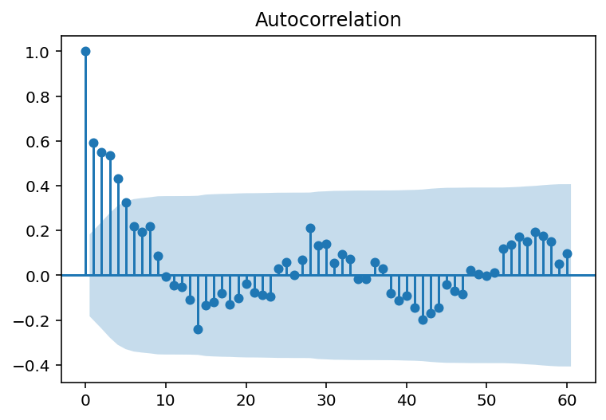

```python
_ = plot_acf(ts, lags=60)
```

↑ In this particular example, it is observed that the strongest positive correlation after the series of negatively correlated lags comes at lag 28. In this regard, 28 is set as the seasonal parameter when generating the simple and dynamic linear models.

```python
from pydlm import dlm, trend, seasonality
```

```python
linear_trend = trend(degree=1, discount=0.9, name='linear_trend', w=10)
seasonal28 = seasonality(period=28, discount=0.9, name='seasonal28', w=10)

simple_dlm = dlm(ts) + linear_trend + seasonal28
simple_dlm.ls()
```

```
The static components are
linear_trend (degree = 2)
seasonal28 (degree = 28)

There is no dynamic component.

There is no automatic component.
```

```python
simple_dlm.fit()
```

```
Initialization finished.
Starting forward filtering...
Forward filtering completed.
Starting backward smoothing...
Backward smoothing completed.
```

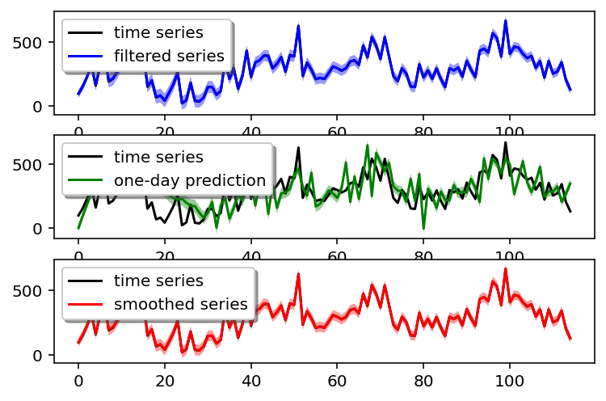

```python
# Plot the fitted results
simple_dlm.turnOff('data points')
simple_dlm.plot()
```

#### Tunning

To the Top

The model is tuned using gradient descent, with the mean squared error as the loss function.

```python
from pydlm import modelTuner
```

```python
%%time

myTuner = modelTuner(method='gradient_descent', loss='mse')
tuned_sDLM = myTuner.tune(simple_dlm, maxit=100)
```

```
The algorithm stops without converging.
Possible reason: some discount is too close to 1 or 0.7 (0.7 is smallest discount that is permissible.
CPU times: user 28.4 s, sys: 352 ms, total: 28.7 s
Wall time: 29.1 s
```

```python
tuned_sDLM.fit()
```

```python
round(np.sqrt(simple_dlm.getMSE()), 4)
round(np.sqrt(tuned_sDLM.getMSE()), 4)
```

```
124.2865
```

```
129.6941
```

↑ tuned simple DLM has higher MSE. Choose `simple_dlm` out of these two.

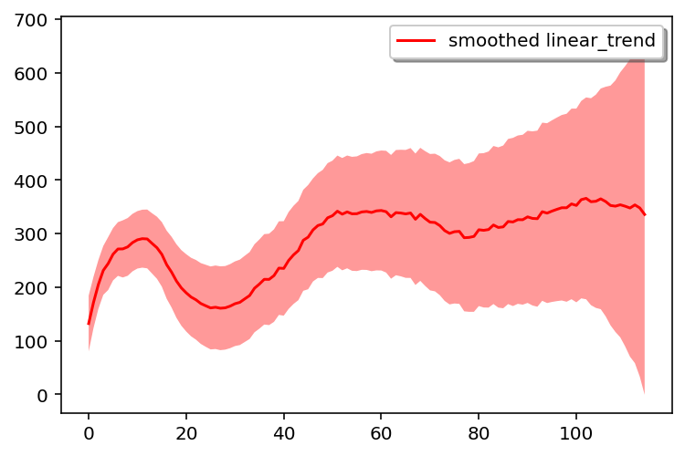

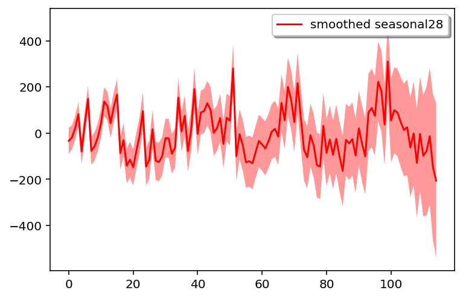

```python
# Plot the linear and seasonal trends.
simple_dlm.turnOff('predict plot')
simple_dlm.turnOff('filtered plot')

simple_dlm.plot('linear_trend')
simple_dlm.plot('seasonal28')
```

#### Forecast Interpretation

To the Top

```python
len(ts)
```

```
115
```

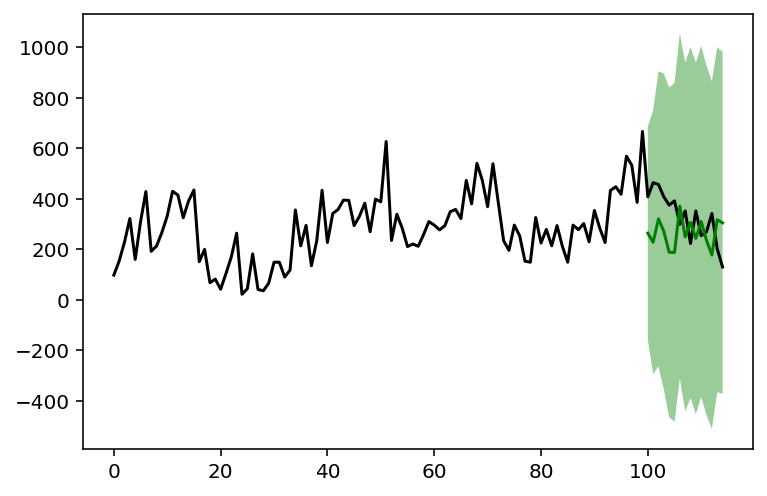

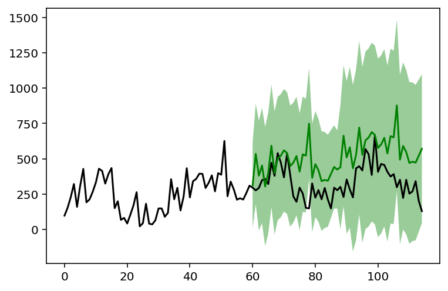

```python
# Plot prediction for the first 100 weeks and a forecast for the following 15 weeks.
simple_dlm.plotPredictN(date=100, N=15)

# Plot prediction for the first 60 weeks and a forecast for the following 55 weeks.
simple_dlm.plotPredictN(date=60, N=55)
```

The prediction plots above show that while the forecast has shown some success in adapting to the structural shift, i.e. the downward shift in trend in the latter of the series - the confidence bands around the series are still quite wide.

This implies uncertainty in the forecasts being constructed - we cannot be confident that the forecasts being made by the model would be accurate across different sets of data.

#### RMSE

To the Top

```python
test = ts[-15:]
len(test)

test.head(2)
test.tail(2)
```

```
15
```

```
Date
2017-05-21    407
2017-05-28    463
Name: IsCanceled, dtype: int64
```

```
Date
2017-08-20    201
2017-08-27    129
Name: IsCanceled, dtype: int64
```

[`predictN()`](https://github.com/wwrechard/pydlm/blob/master/pydlm/predict/dlmPredictMod.py#L110) returns a tuple of two lists:

```
(Predicted observation, variance of the predicted observation)
```

```python
forecast = simple_dlm.predictN(date=100, N=15)[0]

round(np.sqrt(mean_squared_error(test, forecast)), 4)
```

```
141.4244
```

```python
round(np.mean(test), 4)
```

```
327.5333
```

```python
round(141.4244 / 327.5333 * 100, 0)
```

```
43.0
```

## Milestone 2: DLM with Dynamic & Autoregressive Components

To the Top

- dynamic
- [autoReg](https://pydlm.github.io/class_ref.html#autoreg)

```python
from pydlm import autoReg, dynamic
```

```python
# Construct the base
DLM_2 = dlm(ts)
DLM_2 = DLM_2 + trend(1, name='linear_trend', w=1.0)
DLM_2 = DLM_2 + seasonality(28, name='28wks', w=1.0)
DLM_2 = DLM_2 + autoReg(degree=2, name='autoreg2', w=1.0)

# Introduce dynamic component
features = [[1.0, 2.0] for i in range(115)]
ctrend = dynamic(features=features, name='random', discount=0.9)
DLM_2 = DLM_2 + ctrend

# Show the added components
DLM_2.ls()
```

```
The static components are
linear_trend (degree = 2)
28wks (degree = 28)

The dynamic components are
random (dimension = 2)

The automatic components are
autoreg2 (dimension = 2)
```

```python
DLM_2.fit()
```

```
Initialization finished.
Starting forward filtering...
Forward filtering completed.
Starting backward smoothing...
Backward smoothing completed.
```

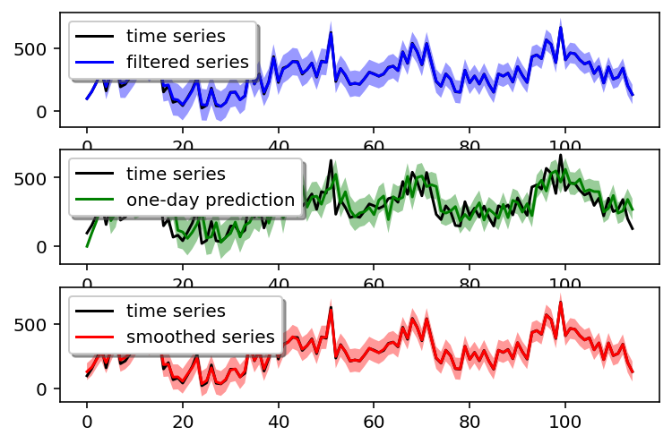

```python
# Plot the fitted results
DLM_2.turnOff('data points')
DLM_2.plot()
```

#### Tunning

To the Top

```python
%%time

myTuner = modelTuner(method='gradient_descent', loss='mse')
tuned_DLM2 = myTuner.tune(DLM_2, maxit=100)
```

```
The algorithm stops without converging.
Possible reason: some discount is too close to 1 or 0.7 (0.7 is smallest discount that is permissible.
CPU times: user 37.4 s, sys: 424 ms, total: 37.8 s
Wall time: 38.2 s
```

```python
tuned_DLM2.fit()
```

```python
round(np.sqrt(DLM_2.getMSE()), 4)
round(np.sqrt(tuned_DLM2.getMSE()), 4)
```

```
110.0252
```

```
107.4558
```

```python
round(np.sqrt(simple_dlm.getMSE()), 4)
round(np.sqrt(tuned_DLM2.getMSE()), 4)
```

```
124.2865
```

```
107.4558
```

#### Forecast Interpretation

To the Top

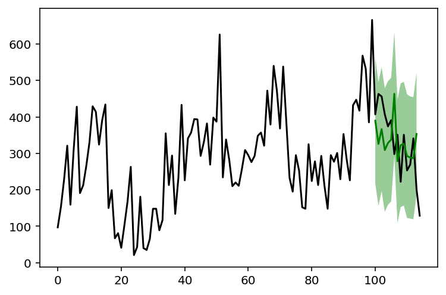

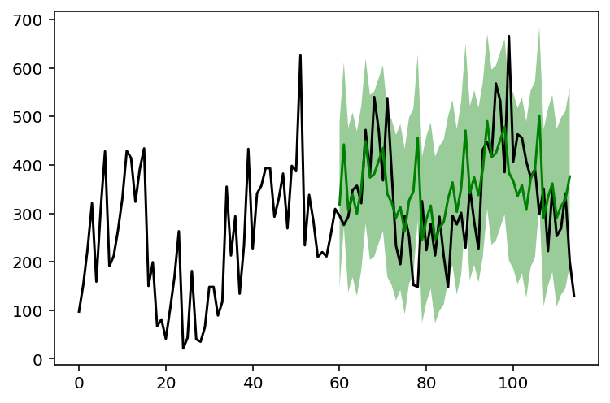

```python
# Plot prediction for the first 100 weeks and a forecast for the following 14 weeks.
tuned_DLM2.plotPredictN(date=100, N=14)

# Plot prediction for the first 60 weeks and a forecast for the following 54 weeks.
tuned_DLM2.plotPredictN(date=60, N=54)
```

#### RMSE

To the Top

```python
test = ts[-15:-1]
len(test)

test.head(2)
test.tail(2)
```

```
14
```

```
Date
2017-05-21    407
2017-05-28    463
Name: IsCanceled, dtype: int64
```

```
Date
2017-08-13    341
2017-08-20    201
Name: IsCanceled, dtype: int64
```

```python
forecast = tuned_DLM2.predictN(date=100, N=14)[0]

round(np.sqrt(mean_squared_error(test, forecast)), 4)
```

```
89.8731
```

```python
round(np.mean(test), 4)
```

```
341.7143
```

```python
round(89.8731 / 341.7143 * 100, 0)
```

```
26.0
```

An RMSE (root mean squared error) of 90 is yielded relative to the mean value of 342 across the test set. The size of the RMSE accounts for 26% of the mean value, indicating that the forecast accuracy has improved when introducing the dynamic and autoregressive components.

While a lower RMSE would be preferable, too low an RMSE value would potentially indicate that the model has been "over-trained" on the training set and will do well in forecasting the test set in question, but may well perform poorly when it comes to forecasting subsequent data. Therefore, while RMSE is important, it is not regarded as the "be all and end all", particularly in the context of a Bayesian model where the objective is to build flexibility into the forecasts to account for state changes.

Given that a visual scan of the predictions indicate that the model is capturing the shift in trends across different periods, this is an indication that the model is working well for these purposes.